# Working with species distribution data in R - YoMos 2026

Yasemin Kukla

## What will we learn and why?

Central question: What is driving species distributions?

Usually, there are many factors to be considered… two main ones being: specific species traits and climate.

Here, we will learn easy first steps for investigating broad distribution patterns, especially helpful when dealing with large scale analysis (e.g. including many species or large geographic areas)

Specifically, we will:

- map the geographic distribution (and richness) of species
- create species richness maps for a discrete trait
- create an average map for a continuous trait
- extract climate variables for the distribution are of a species

## The datasets we use

For the purpose of this workshop, we will only use a specific subset of larger datasets. Here you can find the original data:

- Spatial Data: Global species distribution polygons for terrestrial reptiles [GARD 1.7](https://datadryad.org/dataset/doi:10.5061/dryad.9cnp5hqmb) (Global Assessment of Reptile Distributions)
- Trait Data: Table with numerous traits of reptiles from [ReptTraits](https://figshare.com/articles/dataset/ReptTraits_a_comprehensive_database_of_ecological_traits_in_reptiles/24572683) version 1.2
- Climate Data: annual mean temperature raster (averages from 1981-2010) from [CHELSA](https://www.chelsa-climate.org/datasets/chelsa_bioclim) (Climatologies at high resolution for the earth’s land surface areas) version 2.1

## let’s start with the R code!

1. install and load the required R packages

```r
# install.packages(c("terra", "sf", "exactextractr"))
library(terra)
library(exactextractr)
library(sf)
```

2. load the data (you can find it in ../data/gecko_data/)
   - a trait table (Madagaskar_Gecko_Traits.csv)
   - species distribution polygons (Madagaskar_geckos_GARD1.7.shp)
   - raster of the annual mean temperature in Madagaskar (bio1_Madagaskar.tif)

Our traits table includes 94 gecko species from Madagaskar with their activity time (Nocturnal/Diurnal) and maximum SVL (Snout-Vent Length) in mm

```r
gecko_traits <- read.csv("../data/gecko_data/Madagaskar_Gecko_Traits.csv")
head(gecko_traits)
```

```
  X                 Species Activity max_SVL
1 1   Lygodactylus arnoulti  Diurnal      37
2 2   Lygodactylus bivittis  Diurnal      36
3 3    Lygodactylus blancae  Diurnal      35
4 4     Lygodactylus blanci  Diurnal      39
5 5    Lygodactylus decaryi  Diurnal      27
6 6 Lygodactylus expectatus  Diurnal      31
```

The shapfile includes the spatial distribution polygons of the same 94 gecko species

```r
shp_gecko <- read_sf("../data/gecko_data/Madagaskar_geckos_GARD1.7.shp")
# vect("../data/gecko_data/Madagaskar_geckos_GARD1.7.shp") is also an option
head(shp_gecko)
```

```
Simple feature collection with 6 features and 5 fields
Geometry type: MULTIPOLYGON
Dimension:     XY
Bounding box:  xmin: 45.70559 ymin: -25.04862 xmax: 49.91961 ymax: -12.91748
Geodetic CRS:  WGS 84
# A tibble: 6 × 6
  binomial                TaxonID group  family   area                  geometry
  <chr>                   <chr>   <chr>  <chr>   <dbl>        <MULTIPOLYGON [°]>
1 Lygodactylus arnoulti   R04521  lizard Gekko… 3.46e3 (((47.01337 -20.07518, 4…
2 Lygodactylus bivittis   R04523  lizard Gekko… 2.03e4 (((48.53584 -19.05581, 4…
3 Lygodactylus blancae    R04524  lizard Gekko… 2.04e2 (((46.77706 -19.00618, 4…
4 Lygodactylus blanci     R04525  lizard Gekko… 7.50e1 (((47.04088 -20.17283, 4…
5 Lygodactylus decaryi    R04532  lizard Gekko… 1.40e3 (((45.8007 -24.7462, 45.…
6 Lygodactylus expectatus R04534  lizard Gekko… 1.85e1 (((49.11916 -12.97192, 4…
```

The annual mean temperature (bio1) raster is restricted to the area of Madagaskar

```r
bio1 <- rast("../data/gecko_data/bio1_Madagaskar.tif")
plot(bio1)
```

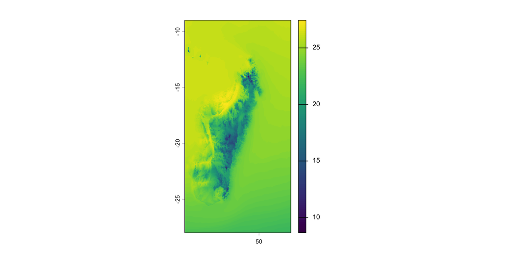

### Task 1: a simple species richness map

```r
shp.a <- shp_gecko[1,] #subset for the first species of the list
richness <- rasterize(shp.a, bio1) # use bio1 raster as a mask layer to rasterize
richness[is.na(richness)] <- 0 # set NAs to 0 for calculations

# for loop to add all species together in one richness raster
for (i in 2:nrow(shp_gecko)){
  shp.i<- shp_gecko[i,]
  rast.i<- rasterize(shp.i, bio1)
  rast.i[is.na(rast.i)] <- 0
  richness <- (rast.i + richness)
}
richness[richness == 0] <- NA # return 0 to NAs
writeRaster(richness, "../data/gecko_data/gecko_sp_richness_Madagascar.tif", overwrite=T) # save for later
```

```r
plot(richness)
```

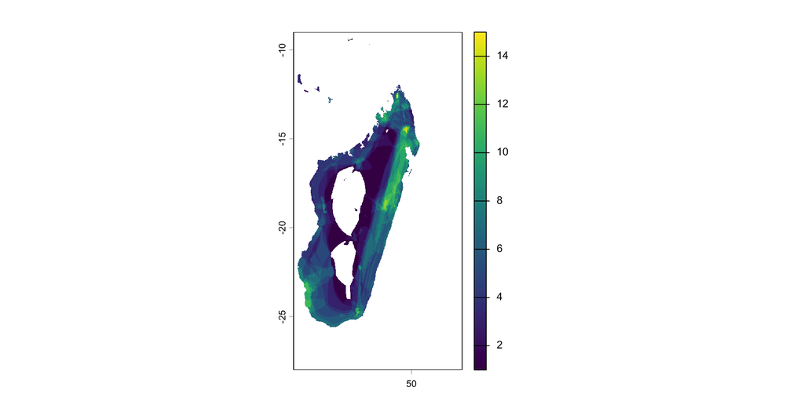

Using the saved .tif file, you can make nice visualizations of the map with softwares like QGIS or ArcGIS

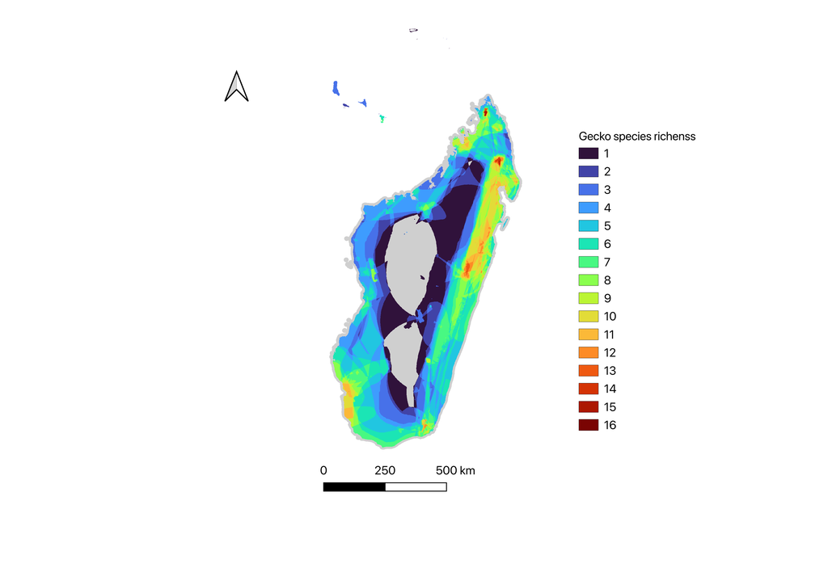

QGIS map of gecko species richness in Madagaskar

### Task 2: mapping a discrete trait

```r
# activity Nocturnal
activity.noc <- subset(gecko_traits, gecko_traits$Activity == "Nocturnal")
shp.a <- subset(shp_gecko, shp_gecko$binomial %in% activity.noc[1,]) #subset for the first species
richness_noc <- rasterize(shp.a, bio1)
richness_noc[is.na(richness_noc)] <- 0

for (i in 2:length(activity.noc$Species)){
  shp.i<- subset(shp_gecko, shp_gecko$binomial == activity.noc$Species[i])
  rast.i<- rasterize(shp.i, bio1)
  rast.i[is.na(rast.i)] <- 0
  richness_noc<- (rast.i + richness_noc)
}

richness_noc[richness_noc == 0] <- NA
writeRaster(richness_noc, "../data/gecko_data/richness_nocturnal_madagaskar.tif", overwrite=T)
```

```r
plot(richness_noc)
```

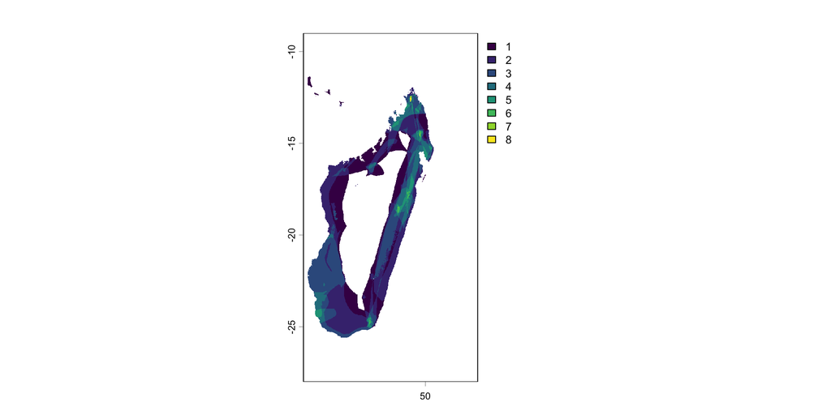

```r
# activity Diurnal
activity.diu <- subset(gecko_traits, gecko_traits$Activity == "Diurnal")
shp.a <- subset(shp_gecko, shp_gecko$binomial  %in% activity.noc[1,]) #subset for the first species
richness_diu <- rasterize(shp.a, bio1)
richness_diu[is.na(richness_diu)] <- 0

for (i in 2:length(activity.diu$Species)){
  shp.i<- subset(shp_gecko, shp_gecko$binomial == activity.diu$Species[i])
  rast.i<- rasterize(shp.i, bio1)
  rast.i[is.na(rast.i)] <- 0
  richness_diu<- (rast.i + richness_diu)
}

richness_diu[richness_diu == 0] <- NA
writeRaster(richness_diu, "../data/gecko_data/richness_diurnal_madagaskar.tif", overwrite=T)
```

```r
plot(richness_diu)
```

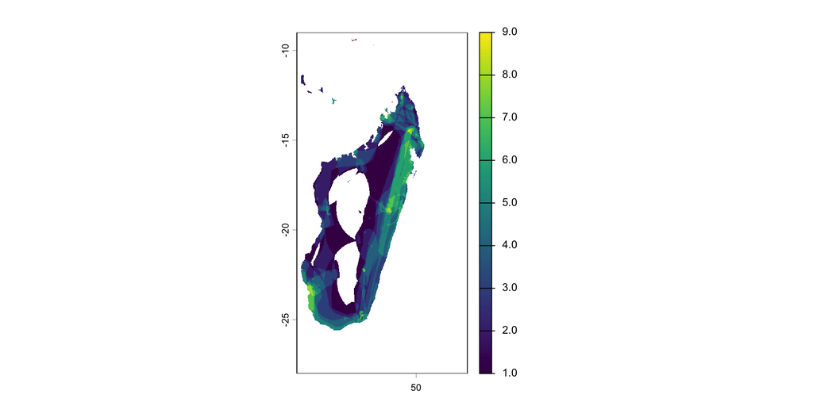

### Task 3: mapping a continuous trait

```r
shp.a <- shp_gecko[1,]
rast.i<- rasterize(shp.a, bio1)
rast.i[is.na(rast.i)] <- 0
SVL.i <- max(gecko_traits$max_SVL[1])
richness_SVL <- classify(rast.i, cbind(1, SVL.i)) # 1s in the raster get replaced with the max SVL value

for (i in 2:nrow(shp_gecko)){
  shp.i <- shp_gecko[i,]
  rast.i<- rasterize(shp.i, bio1)
  rast.i[is.na(rast.i)] <- 0
    SVL.i <- max(gecko_traits$max_SVL[i])
    rast.i <- classify(rast.i, cbind(1, SVL.i))
    richness_SVL<- (rast.i + richness_SVL)
}

richness_SVL[richness_SVL == 0] <- NA
overall_richness <- rast("../data/gecko_data/gecko_sp_richness_Madagascar.tif")
average_SVL <- richness_SVL/overall_richness
```

```r
plot(average_SVL)
```

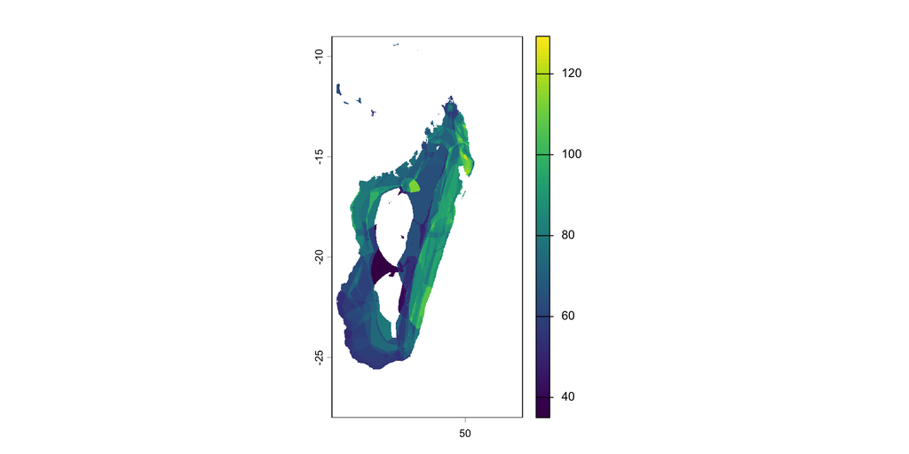

### Task 4: extracting climate data

```r
res_complete <- c()
for (i in 1:length(shp_gecko)) {
  shp.i <- shp_gecko[i,]
  clim.i <- exact_extract(bio1, shp.i, c("stdev", "median")) #extracting the standard deviation and the median of all four CHELSA variables
  res.i <- cbind(shp.i$binomial, clim.i)
  colnames(res.i) <- c("Species", "stdev_bio1", "median_bio")
  res_complete <- rbind(res_complete, res.i)
}
head(res_complete)
```

```
                  Species stdev_bio1 median_bio
1   Lygodactylus arnoulti 2.17190719   18.90843
2   Lygodactylus bivittis 1.39239967   19.01665
3    Lygodactylus blancae 0.66913438   19.51448
4     Lygodactylus blanci 1.37661302   15.63858
5    Lygodactylus decaryi 0.58408403   23.58876
6 Lygodactylus expectatus 0.07865568   25.49256
```

```r
write.csv(res_complete, "../data/gecko_data/CHELSA_madagaskar_gecko.csv")
```

## Conclusions

- continuous and discrete traits can be mapped to show the biogeography of a trait –> often a helpful first step when investigating broader patterns
- we can easily extract climate data from within a species distribution to find out about the climatic conditions said species occupies

Any further questions? Don’t hesitate to reach out during the seminar or afterwards via email: ykukla@uni-bonn.de